# DLC Analysis for stroke

## DeepLabCut based analysis for behavioral profiling of rodent stroke recovery

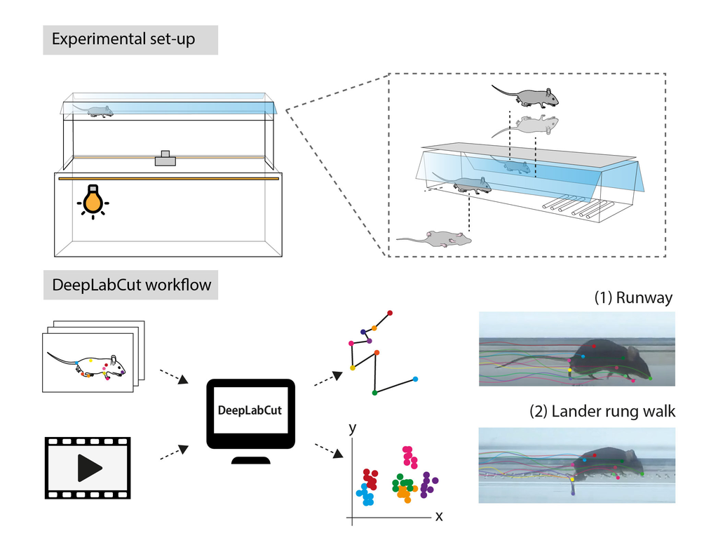

Fig. 1: Graphical overview

### (1) BEFORE YOU START

- Download the entire data set including the raw files, and the R script. The script was tested on Windows and Mac under the R Version 3.8
- Do not change the order structure or rename the files, this may cause errors in the script.
- Note that the .csv files represent the output from DeepLabCut. We have randomly selected representative videos to give you an example of the data processing. Due to the random selection the output files do not necessarily show the same findings as described in the manuscript. If your set-up is different you may need to adapt the script. You are welcome to contact ruslan.rust@irem.uzh.ch for further help / collaboration.

### (2) INITIAL USAGE

- Please make sure that all packages are correctly installed. If packages are not correctly installed, please manually upgrade your packages.
- Run the entire code. You may receive some warnings but you should not receive any errors when running the code. If you receive an error try to resolve the error or you are welcome to contact me for further help.
- You can check the “Html Files” and the Output packages for confirmation

### (3) REGULAR USE

- Please let us know if you identify errors or you made improvements to the script, we will try to continuously update the code